# Case 1 (Bitcoin): Exploratory Data Analysis

Chino Louis Lorenzo S. Meneses

November 01, 2026

# 1 Purpose and scope

This case study asks which global financial conditions and Philippine macro-financial variables are associated with monthly Bitcoin log returns. This document only describes and checks the data: it audits the cleaned dataset, summarizes each variable, and examines distributions, relationships and possible problems (outliers, persistence, correlated regressors). No variable selection or final model choice happens here; those decisions belong to the modeling stage.

The sample is monthly, from January 2018 to December 2025 (96 observations). `BTC_Return`, the monthly log return of Bitcoin, is the dependent variable. The eight candidate regressors are `SP500`, `USD_Index`, `US_10Y_Yield`, `VIX`, `Philippine_M3_growth`, `BSP_RRP_Rate`, `USD_PHP` and `WTI`. All relationships reported below are descriptive: they show association, not causation.

# 2 Data import and audit

## 2.1 Import the cleaned dataset

```r
f_main <- find_data("BTC_regression_ready.csv")
cat("Reading:", f_main, "\n")
```

```
## Reading: C:/Users/mchin/OneDrive/Desktop/College/7 (1st Term)/FINARTS/R Project/CASE 1 - Bitcoin (BTC) - EDA/01 - Data/BTC_regression_ready.csv
```

```r
dat <- read_csv(f_main,
                col_types = cols(date = col_date(format = "%Y-%m-%d"), .default = col_double())) %>%
  arrange(date)

y_var    <- "BTC_Return"                              # dependent variable
x_vars   <- setdiff(names(dat), c("date", y_var))     # the eight regressors
all_vars <- c(y_var, x_vars)

# Helper: wide -> long, with variables kept in their original order for plotting
to_long <- function(df, vars = all_vars) {
  df %>%
    dplyr::select(date, all_of(vars)) %>%
    pivot_longer(all_of(vars), names_to = "variable", values_to = "value") %>%
    mutate(variable = factor(variable, levels = vars))
}

head(dat)
```

| date | BTC_Return | SP500 | USD_Index | US_10Y_Yield | VIX | Philippine_M3_growth | BSP_RRP_Rate | USD_PHP | WTI |
| --- | --- | --- | --- | --- | --- | --- | --- | --- | --- |
| 2018-01-01 | -0.32571267 | 0.054657418 | -0.030518689 | 0.32 | 11.06238 | 12.99698 | 0.00 | 0.029564831 | 0.06963221 |
| 2018-02-01 | 0.01714973 | -0.039726116 | 0.015065360 | 0.15 | 22.46474 | 13.63165 | 0.00 | 0.011850702 | -0.05371588 |
| 2018-03-01 | -0.39948238 | -0.027252513 | -0.008448704 | -0.13 | 19.02381 | 14.39913 | 0.00 | 0.003319234 | 0.05448695 |
| 2018-04-01 | 0.28147986 | 0.002715112 | 0.017138556 | 0.21 | 18.26762 | 14.27462 | 0.00 | -0.004646170 | 0.05532401 |
| 2018-05-01 | -0.20947601 | 0.021378202 | 0.023975770 | -0.12 | 14.12455 | 14.36136 | 0.25 | 0.013836290 | -0.02331521 |
| 2018-06-01 | -0.15720258 | 0.004830713 | 0.011269476 | 0.02 | 13.67810 | 11.81311 | 0.25 | 0.015686079 | 0.10142624 |

```r
# BTC_monthly_cleaned_all.csv and BTC_regression_ready.csv: are they the same file?
f_alt <- tryCatch(find_data("BTC_monthly_cleaned_all.csv"), error = function(e) NA_character_)
if (!is.na(f_alt)) {
  same <- unname(tools::md5sum(f_main) == tools::md5sum(f_alt))
  cat("BTC_monthly_cleaned_all.csv is byte-for-byte identical to BTC_regression_ready.csv:", same, "\n")
} else {
  cat("BTC_monthly_cleaned_all.csv not found (not needed for the analysis).\n")
}
```

```
## BTC_monthly_cleaned_all.csv is byte-for-byte identical to BTC_regression_ready.csv: TRUE
```

## 2.2 Check structure and integrity

```r
glimpse(dat)
```

```
## Rows: 96
## Columns: 10
## $ date                 <date> 2018-01-01, 2018-02-01, 2018-03-01, 2018-04-01, …
## $ BTC_Return           <dbl> -0.32571267, 0.01714973, -0.39948238, 0.28147986,…
## $ SP500                <dbl> 0.054657418, -0.039726116, -0.027252513, 0.002715…
## $ USD_Index            <dbl> -0.0305186889, 0.0150653598, -0.0084487045, 0.017…
## $ US_10Y_Yield         <dbl> 0.32, 0.15, -0.13, 0.21, -0.12, 0.02, 0.11, -0.10…
## $ VIX                  <dbl> 11.06238, 22.46474, 19.02381, 18.26762, 14.12455,…
## $ Philippine_M3_growth <dbl> 12.996979, 13.631647, 14.399129, 14.274621, 14.36…
## $ BSP_RRP_Rate         <dbl> 0.00, 0.00, 0.00, 0.00, 0.25, 0.25, 0.00, 0.50, 0…
## $ USD_PHP              <dbl> 0.0295648309, 0.0118507017, 0.0033192344, -0.0046…
## $ WTI                  <dbl> 0.0696322084, -0.0537158825, 0.0544869520, 0.0553…
```

```r
cat("Rows:", nrow(dat), "| Columns:", ncol(dat), "\n")
```

```
## Rows: 96 | Columns: 10
```

```r
cat("Any missing values:", anyNA(dat), "\n")
```

```
## Any missing values: FALSE
```

```r
cat("Sample period:", format(min(dat$date)), "to", format(max(dat$date)), "\n")
```

```
## Sample period: 2018-01-01 to 2025-12-01
```

```r
# Consecutive dates should be exactly one month apart
gap_months <- interval(head(dat$date, -1), tail(dat$date, -1)) %/% months(1)
cat("Months between consecutive dates (should only show 1):",
    paste(sort(unique(gap_months)), collapse = ", "), "\n")
```

```
## Months between consecutive dates (should only show 1): 1
```

```r
# Missing values per variable
colSums(is.na(dat))
```

```
##                 date           BTC_Return                SP500
##                    0                    0                    0
##            USD_Index         US_10Y_Yield                  VIX
##                    0                    0                    0
## Philippine_M3_growth         BSP_RRP_Rate              USD_PHP
##                    0                    0                    0
##                  WTI
##                    0
```

```r
summary(dat)
```

```
##       date              BTC_Return           SP500
##  Min.   :2018-01-01   Min.   :-0.47431   Min.   :-0.133668
##  1st Qu.:2019-12-24   1st Qu.:-0.07934   1st Qu.:-0.017971
##  Median :2021-12-16   Median : 0.01232   Median : 0.019441
##  Mean   :2021-12-15   Mean   : 0.01897   Mean   : 0.009793
##  3rd Qu.:2023-12-08   3rd Qu.: 0.12675   3rd Qu.: 0.039311
##  Max.   :2025-12-01   Max.   : 0.47156   Max.   : 0.119421
##    USD_Index           US_10Y_Yield           VIX        Philippine_M3_growth
##  Min.   :-0.0330187   Min.   :-0.52000   Min.   :11.06   Min.   : 4.707
##  1st Qu.:-0.0114924   1st Qu.:-0.13000   1st Qu.:15.41   1st Qu.: 6.332
##  Median :-0.0007912   Median : 0.01000   Median :18.34   Median : 7.255
##  Mean   : 0.0008768   Mean   : 0.01854   Mean   :19.73   Mean   : 8.265
##  3rd Qu.: 0.0137557   3rd Qu.: 0.18000   3rd Qu.:22.40   3rd Qu.: 9.468
##  Max.   : 0.0405848   Max.   : 0.68000   Max.   :57.74   Max.   :16.207
##   BSP_RRP_Rate         USD_PHP               WTI
##  Min.   :-0.50000   Min.   :-0.041003   Min.   :-0.7819650
##  1st Qu.: 0.00000   1st Qu.:-0.007310   1st Qu.:-0.0611311
##  Median : 0.00000   Median : 0.000286   Median : 0.0056077
##  Mean   : 0.01562   Mean   : 0.001706   Mean   :-0.0005665
##  3rd Qu.: 0.00000   3rd Qu.: 0.012053   3rd Qu.: 0.0607122
##  Max.   : 0.75000   Max.   : 0.051809   Max.   : 0.6150310
```

```r
# Observed minimum and maximum of each variable
obs_range <- dat %>%
  summarise(across(all_of(all_vars), list(min = min, max = max))) %>%
  pivot_longer(everything(), names_to = c("variable", ".value"),
               names_pattern = "^(.*)_(min|max)$")
ft(obs_range, digits = 4, name = "audit_observed_ranges")
```

| variable | min | max |
| --- | --- | --- |
| BTC_Return | -0.4743 | 0.4716 |
| SP500 | -0.1337 | 0.1194 |
| USD_Index | -0.0330 | 0.0406 |
| US_10Y_Yield | -0.5200 | 0.6800 |
| VIX | 11.0624 | 57.7368 |
| Philippine_M3_growth | 4.7071 | 16.2065 |
| BSP_RRP_Rate | -0.5000 | 0.7500 |
| USD_PHP | -0.0410 | 0.0518 |
| WTI | -0.7820 | 0.6150 |

```r
# Cross-check: recompute every cleaned variable from the levels file and compare.
# NOTE: BTC_monthly_levels.csv reuses the same column names, but the column "BTC_Return"
# there actually holds the BTC PRICE, so it is renamed to BTC_Price here.
f_lv <- find_data("BTC_monthly_levels.csv")
lv <- read_csv(f_lv, col_types = cols(date = col_date(format = "%Y-%m-%d"), .default = col_double())) %>%
  arrange(date) %>%
  rename(BTC_Price = BTC_Return)

recomputed <- lv %>%
  transmute(date,
            BTC_Return           = c(NA, diff(log(BTC_Price))),
            SP500                = c(NA, diff(log(SP500))),
            USD_Index            = c(NA, diff(log(USD_Index))),
            US_10Y_Yield         = c(NA, diff(US_10Y_Yield)),
            VIX                  = VIX,
            Philippine_M3_growth = Philippine_M3_growth,
            BSP_RRP_Rate         = c(NA, diff(BSP_RRP_Rate)),
            USD_PHP              = c(NA, diff(log(USD_PHP))),
            WTI                  = c(NA, diff(log(WTI)))) %>%
  filter(date %in% dat$date) %>%
  arrange(date)

stopifnot(identical(recomputed$date, dat$date))

recon_tbl <- tibble(variable = all_vars,
                    max_abs_difference = map_dbl(all_vars, ~ max(abs(recomputed[[.x]] - dat[[.x]]))),
                    reconciles = max_abs_difference < 1e-8)
ft(recon_tbl, digits = 12, name = "audit_reconciliation")
```

| variable | max_abs_difference | reconciles |
| --- | --- | --- |
| BTC_Return | 0.000000000000 | true |
| SP500 | 0.000000000000 | true |
| USD_Index | 0.000000000000 | true |
| US_10Y_Yield | 0.000000000000 | true |
| VIX | 0.000000000000 | true |
| Philippine_M3_growth | 0.000000000000 | true |
| BSP_RRP_Rate | 0.000000000000 | true |
| USD_PHP | 0.000000000000 | true |
| WTI | 0.000000000000 | true |

The cleaned dataset has N = 96 monthly observations and 10 columns (the date plus nine numeric variables), covering January 2018 to December 2025. There are no missing values, and consecutive dates are exactly one month apart, so the monthly series is complete. (The levels file has 97 rows because December 2017 is the starting point needed to compute the first differences and log returns.)

The documented ranges from the header of the cleaning script were not available for this document. Instead, every cleaned variable was recomputed from `BTC_monthly_levels.csv` (log returns for BTC, S&P 500, the dollar index, USD/PHP and WTI; first differences for the 10-year yield and the BSP rate; levels for VIX and M3 growth). All nine variables reconcile with the cleaned file to within floating-point error (differences below $10^{-15}$), and the observed minimums and maximums are economically plausible. The audit therefore found no data integrity problems and confirms that the cleaning transformations were applied as described.

## 2.3 Data description table

```r
# Transformations and units below were verified numerically in the reconciliation chunk above.
# The BSP source is taken from the header of BSP_RRP_Rate.csv; for the other series the data
# providers are listed in the variable summary of BTC_Data_Cleaning.R.
var_info <- tribble(
  ~variable,              ~meaning,                                         ~transformation,                                      ~unit,                                 ~type,          ~source,
  "BTC_Return",           "Bitcoin monthly return (dependent variable)",     "Log return: ln(P_t / P_t-1) of the monthly BTC price", "Decimal (0.01 = about 1%)",            "log_return",   "See BTC_Data_Cleaning.R",
  "SP500",                "S&P 500 equity index return",                     "Log return of the monthly index level",              "Decimal (0.01 = about 1%)",           "log_return",   "See BTC_Data_Cleaning.R",
  "USD_Index",            "US dollar index return",                          "Log return of the monthly index level",              "Decimal (0.01 = about 1%)",           "log_return",   "See BTC_Data_Cleaning.R",
  "US_10Y_Yield",         "US 10-year Treasury yield",                       "First difference of the monthly yield (level change)", "Percentage points",                 "pp_change",    "See BTC_Data_Cleaning.R",
  "VIX",                  "CBOE volatility index (market fear gauge)",       "Level (monthly average of daily values), not differenced",                             "Index points",                        "index_level",  "See BTC_Data_Cleaning.R",
  "Philippine_M3_growth", "Growth of Philippine M3 money supply",            "Year-on-year growth, as built in the cleaning script", "Percent",            "pct_growth",   "See BTC_Data_Cleaning.R",
  "BSP_RRP_Rate",         "Change in the BSP target reverse repurchase (RRP) rate", "First difference of the end-of-month target RRP rate", "Percentage points",       "pp_change",    "Bangko Sentral ng Pilipinas (Selected Domestic Interest Rates, Target RRP Rate)",
  "USD_PHP",              "Peso per US dollar exchange rate return (positive = peso depreciation)", "Log return of the monthly exchange rate", "Decimal (0.01 = about 1%)",    "log_return",   "See BTC_Data_Cleaning.R",
  "WTI",                  "WTI crude oil price return",                      "Log return of the monthly price",                    "Decimal (0.01 = about 1%)",           "log_return",   "See BTC_Data_Cleaning.R"
)

ft(var_info %>% dplyr::select(-type), digits = 3, name = "data_description")
```

| variable | meaning | transformation | unit | source |
| --- | --- | --- | --- | --- |
| BTC_Return | Bitcoin monthly return (dependent variable) | Log return: ln(P_t / P_t-1) of the monthly BTC price | Decimal (0.01 = about 1%) | See BTC_Data_Cleaning.R |
| SP500 | S&P 500 equity index return | Log return of the monthly index level | Decimal (0.01 = about 1%) | See BTC_Data_Cleaning.R |
| USD_Index | US dollar index return | Log return of the monthly index level | Decimal (0.01 = about 1%) | See BTC_Data_Cleaning.R |
| US_10Y_Yield | US 10-year Treasury yield | First difference of the monthly yield (level change) | Percentage points | See BTC_Data_Cleaning.R |
| VIX | CBOE volatility index (market fear gauge) | Level (monthly average of daily values), not differenced | Index points | See BTC_Data_Cleaning.R |
| Philippine_M3_growth | Growth of Philippine M3 money supply | Year-on-year growth, as built in the cleaning script | Percent | See BTC_Data_Cleaning.R |
| BSP_RRP_Rate | Change in the BSP target reverse repurchase (RRP) rate | First difference of the end-of-month target RRP rate | Percentage points | Bangko Sentral ng Pilipinas (Selected Domestic Interest Rates, Target RRP Rate) |
| USD_PHP | Peso per US dollar exchange rate return (positive = peso depreciation) | Log return of the monthly exchange rate | Decimal (0.01 = about 1%) | See BTC_Data_Cleaning.R |
| WTI | WTI crude oil price return | Log return of the monthly price | Decimal (0.01 = about 1%) | See BTC_Data_Cleaning.R |

The variables are measured in different units. `BTC_Return`, `SP500`, `USD_Index`, `USD_PHP` and `WTI` are decimal log returns (0.01 is about 1%), `US_10Y_Yield` and `BSP_RRP_Rate` are changes in percentage points, `VIX` is an index level in points, and `Philippine_M3_growth` is a year-on-year growth rate in percent. This matters when reading regression coefficients later: a coefficient on a return variable is the BTC response to a one unit (100%) log return, a coefficient on `VIX` is the response to one index point, and so on, so raw coefficient sizes are not comparable across regressors. The one standard deviation table in the next section puts the regressors on a common footing for judging economic significance. Note also that `VIX` and `Philippine_M3_growth` are levels while the other regressors and the dependent variable are changes or returns.

The levels file `BTC_monthly_levels.csv` reuses the same column names for price and level data: its `BTC_Return` column actually holds the BTC price in US dollars, and `SP500`, `USD_Index` and the others hold index levels. That file is therefore not a regression input and was used here only for the reconciliation.

# 3 Descriptive statistics

## 3.1 Summary statistics for all variables

For a sample $x_1,\dots,x_n$ with mean $\bar{x}$ and central moments $m_k = \frac{1}{n}\sum_{i}(x_i-\bar{x})^k$:

$$\text{skewness} = \frac{m_3}{m_2^{3/2}}, \qquad
\text{kurtosis} = \frac{m_4}{m_2^{2}}, \qquad
\text{excess kurtosis} = \text{kurtosis} - 3 .$$

A normal distribution has skewness 0 and kurtosis 3 (excess kurtosis 0).

```r
desc_tbl <- dat %>%
  dplyr::select(all_of(all_vars)) %>%
  pivot_longer(everything(), names_to = "variable", values_to = "value") %>%
  group_by(variable) %>%
  summarise(n = n(),
            mean = mean(value),
            median = median(value),
            sd = sd(value),
            min = min(value),
            max = max(value),
            skewness = moments::skewness(value),
            kurtosis = moments::kurtosis(value),
            excess_kurtosis = kurtosis - 3,
            .groups = "drop") %>%
  mutate(variable = factor(variable, levels = all_vars)) %>%
  arrange(variable) %>%
  mutate(variable = as.character(variable))

ft(desc_tbl, digits = 4, name = "descriptive_statistics")
```

| variable | n | mean | median | sd | min | max | skewness | kurtosis | excess_kurtosis |
| --- | --- | --- | --- | --- | --- | --- | --- | --- | --- |
| BTC_Return | 96 | 0.0190 | 0.0123 | 0.1916 | -0.4743 | 0.4716 | -0.1365 | 3.0538 | 0.0538 |
| SP500 | 96 | 0.0098 | 0.0194 | 0.0477 | -0.1337 | 0.1194 | -0.5967 | 3.2852 | 0.2852 |
| USD_Index | 96 | 0.0009 | -0.0008 | 0.0160 | -0.0330 | 0.0406 | 0.0324 | 2.4972 | -0.5028 |
| US_10Y_Yield | 96 | 0.0185 | 0.0100 | 0.2569 | -0.5200 | 0.6800 | 0.0533 | 2.8006 | -0.1994 |
| VIX | 96 | 19.7319 | 18.3355 | 6.7634 | 11.0624 | 57.7368 | 2.3679 | 12.4983 | 9.4983 |
| Philippine_M3_growth | 96 | 8.2645 | 7.2551 | 2.7698 | 4.7071 | 16.2065 | 1.1684 | 3.4610 | 0.4610 |
| BSP_RRP_Rate | 96 | 0.0156 | 0.0000 | 0.2201 | -0.5000 | 0.7500 | 0.9022 | 5.4853 | 2.4853 |
| USD_PHP | 96 | 0.0017 | 0.0003 | 0.0158 | -0.0410 | 0.0518 | 0.5588 | 4.1094 | 1.1094 |
| WTI | 96 | -0.0006 | 0.0056 | 0.1356 | -0.7820 | 0.6150 | -1.1059 | 16.8619 | 13.8619 |

```r
# Quick overview with mini histograms
skim(dat)
```

Data summary

| Name | dat |
| --- | --- |
| Number of rows | 96 |
| Number of columns | 10 |
| _______________________ |  |
| Column type frequency: |  |
| Date | 1 |
| numeric | 9 |
| ________________________ |  |
| Group variables | None |

**Variable type: Date**

| skim_variable | n_missing | complete_rate | min | max | median | n_unique |
| --- | --- | --- | --- | --- | --- | --- |
| date | 0 | 1 | 2018-01-01 | 2025-12-01 | 2021-12-16 | 96 |

**Variable type: numeric**

| skim_variable | n_missing | complete_rate | mean | sd | p0 | p25 | p50 | p75 | p100 | hist |
| --- | --- | --- | --- | --- | --- | --- | --- | --- | --- | --- |
| BTC_Return | 0 | 1 | 0.02 | 0.19 | -0.47 | -0.08 | 0.01 | 0.13 | 0.47 | ▁▃▇▅▂ |
| SP500 | 0 | 1 | 0.01 | 0.05 | -0.13 | -0.02 | 0.02 | 0.04 | 0.12 | ▁▂▅▇▁ |
| USD_Index | 0 | 1 | 0.00 | 0.02 | -0.03 | -0.01 | 0.00 | 0.01 | 0.04 | ▂▇▇▇▁ |
| US_10Y_Yield | 0 | 1 | 0.02 | 0.26 | -0.52 | -0.13 | 0.01 | 0.18 | 0.68 | ▃▇▇▃▂ |
| VIX | 0 | 1 | 19.73 | 6.76 | 11.06 | 15.41 | 18.34 | 22.40 | 57.74 | ▇▃▁▁▁ |
| Philippine_M3_growth | 0 | 1 | 8.26 | 2.77 | 4.71 | 6.33 | 7.26 | 9.47 | 16.21 | ▇▅▂▂▁ |
| BSP_RRP_Rate | 0 | 1 | 0.02 | 0.22 | -0.50 | 0.00 | 0.00 | 0.00 | 0.75 | ▂▇▁▁▁ |
| USD_PHP | 0 | 1 | 0.00 | 0.02 | -0.04 | -0.01 | 0.00 | 0.01 | 0.05 | ▁▆▇▂▁ |
| WTI | 0 | 1 | 0.00 | 0.14 | -0.78 | -0.06 | 0.01 | 0.06 | 0.62 | ▁▁▇▃▁ |

```r
# Finance-oriented summary (note: Kurtosis reported here is EXCESS kurtosis)
dat_xts <- xts(dat[, all_vars], order.by = dat$date)
table.Stats(dat_xts) %>%
  as.data.frame() %>%
  rownames_to_column("statistic") %>%
  ft(digits = 4, name = "descriptive_table_stats")
```

| statistic | BTC_Return | SP500 | USD_Index | US_10Y_Yield | VIX | Philippine_M3_growth | BSP_RRP_Rate | USD_PHP | WTI |
| --- | --- | --- | --- | --- | --- | --- | --- | --- | --- |
| Observations | 96.0000 | 96.0000 | 96.0000 | 96.0000 | 96.0000 | 96.0000 | 96.0000 | 96.0000 | 96.0000 |
| NAs | 0.0000 | 0.0000 | 0.0000 | 0.0000 | 0.0000 | 0.0000 | 0.0000 | 0.0000 | 0.0000 |
| Minimum | -0.4743 | -0.1337 | -0.0330 | -0.5200 | 11.0624 | 4.7071 | -0.5000 | -0.0410 | -0.7820 |
| Quartile 1 | -0.0793 | -0.0180 | -0.0115 | -0.1300 | 15.4086 | 6.3317 | 0.0000 | -0.0073 | -0.0611 |
| Median | 0.0123 | 0.0194 | -0.0008 | 0.0100 | 18.3355 | 7.2551 | 0.0000 | 0.0003 | 0.0056 |
| Arithmetic Mean | 0.0190 | 0.0098 | 0.0009 | 0.0185 | 19.7319 | 8.2645 | 0.0156 | 0.0017 | -0.0006 |
| Geometric Mean | -0.0001 | 0.0087 | 0.0008 | -0.0158 | 18.8902 | 7.9128 | -0.0073 | 0.0016 | -0.0137 |
| Quartile 3 | 0.1267 | 0.0393 | 0.0138 | 0.1800 | 22.3968 | 9.4681 | 0.0000 | 0.0121 | 0.0607 |
| Maximum | 0.4716 | 0.1194 | 0.0406 | 0.6800 | 57.7368 | 16.2065 | 0.7500 | 0.0518 | 0.6150 |
| SE Mean | 0.0196 | 0.0049 | 0.0016 | 0.0262 | 0.6903 | 0.2827 | 0.0225 | 0.0016 | 0.0138 |
| LCL Mean (0.95) | -0.0198 | 0.0001 | -0.0024 | -0.0335 | 18.3615 | 7.7033 | -0.0290 | -0.0015 | -0.0280 |
| UCL Mean (0.95) | 0.0578 | 0.0195 | 0.0041 | 0.0706 | 21.1023 | 8.8257 | 0.0602 | 0.0049 | 0.0269 |
| Variance | 0.0367 | 0.0023 | 0.0003 | 0.0660 | 45.7434 | 7.6716 | 0.0484 | 0.0002 | 0.0184 |
| Stdev | 0.1916 | 0.0477 | 0.0160 | 0.2569 | 6.7634 | 2.7698 | 0.2201 | 0.0158 | 0.1356 |
| Skewness | -0.1365 | -0.5967 | 0.0324 | 0.0533 | 2.3679 | 1.1684 | 0.9022 | 0.5588 | -1.1059 |
| Kurtosis | 0.0538 | 0.2852 | -0.5028 | -0.1994 | 9.4983 | 0.4610 | 2.4853 | 1.1094 | 13.8619 |

## 3.2 BTC volatility and one standard deviation moves

With monthly standard deviation $\sigma_m$ and independent months, the annualized volatility is

$$\sigma_{\text{ann}} = \sigma_m \sqrt{12}.$$

For a log return, a one standard deviation move of size $\sigma$ corresponds to a simple change of $e^{\sigma}-1$.

```r
ret_vars <- var_info %>% filter(type == "log_return") %>% pull(variable)

vol_tbl <- tibble(variable = ret_vars,
                  monthly_sd = map_dbl(ret_vars, ~ sd(dat[[.x]]))) %>%
  mutate(annualized_vol = monthly_sd * sqrt(12),
         annualized_vol_pct = 100 * annualized_vol)
ft(vol_tbl, digits = 4, name = "annualized_volatility")
```

| variable | monthly_sd | annualized_vol | annualized_vol_pct |
| --- | --- | --- | --- |
| BTC_Return | 0.1916 | 0.6637 | 66.3680 |
| SP500 | 0.0477 | 0.1652 | 16.5202 |
| USD_Index | 0.0160 | 0.0553 | 5.5316 |
| USD_PHP | 0.0158 | 0.0548 | 5.4761 |
| WTI | 0.1356 | 0.4697 | 46.9731 |

```r
# Size of a one standard deviation move for every variable, in its own units
sd_tbl <- var_info %>%
  mutate(sd = map_dbl(variable, ~ sd(dat[[.x]])),
         one_sd_move = case_when(
           type == "log_return"  ~ sprintf("about %.1f%% (log-return sd = %.4f)", 100 * (exp(sd) - 1), sd),
           type == "pp_change"   ~ sprintf("%.3f percentage points", sd),
           type == "index_level" ~ sprintf("%.2f index points", sd),
           type == "pct_growth"  ~ sprintf("%.2f percentage points of growth", sd))) %>%
  dplyr::select(variable, unit, sd, one_sd_move)
ft(sd_tbl, digits = 4, name = "one_sd_moves")
```

| variable | unit | sd | one_sd_move |
| --- | --- | --- | --- |
| BTC_Return | Decimal (0.01 = about 1%) | 0.1916 | about 21.1% (log-return sd = 0.1916) |
| SP500 | Decimal (0.01 = about 1%) | 0.0477 | about 4.9% (log-return sd = 0.0477) |
| USD_Index | Decimal (0.01 = about 1%) | 0.0160 | about 1.6% (log-return sd = 0.0160) |
| US_10Y_Yield | Percentage points | 0.2569 | 0.257 percentage points |
| VIX | Index points | 6.7634 | 6.76 index points |
| Philippine_M3_growth | Percent | 2.7698 | 2.77 percentage points of growth |
| BSP_RRP_Rate | Percentage points | 0.2201 | 0.220 percentage points |
| USD_PHP | Decimal (0.01 = about 1%) | 0.0158 | about 1.6% (log-return sd = 0.0158) |
| WTI | Decimal (0.01 = about 1%) | 0.1356 | about 14.5% (log-return sd = 0.1356) |

Bitcoin is by far the most volatile series. Its monthly standard deviation is 0.192 (a one standard deviation move is about 21% in simple terms), or roughly 66% annualized. That is about four times the S&P 500 (4.8% monthly, 16.5% annualized) and well above WTI (13.6% monthly, 47% annualized), the dollar index (1.6% monthly, 5.5% annualized) and USD/PHP (1.6% monthly, 5.5% annualized). The average monthly BTC log return is 0.019 (median 0.012), but with a standard error of about 0.020 the mean cannot be distinguished from zero (t of about 1.0): the noise is large relative to the average drift. The best month was May 2019 (+0.47 log, about +60%) and the worst was June 2022 (−0.47 log, about −38%).

Among the regressors, `VIX` and `WTI` are the most unusual. `VIX` is strongly right skewed (skewness 2.37, kurtosis 12.5) and `WTI` is left skewed (−1.11) with kurtosis of 16.9; both are driven by March to May 2020. `Philippine_M3_growth` is right skewed (1.17), `BSP_RRP_Rate` has kurtosis of 5.5 because most months are zero with a few large moves, and `SP500` (−0.60) and `USD_PHP` (0.56) are mildly skewed. `USD_Index` and `US_10Y_Yield` are close to symmetric.

For `BTC_Return`, kurtosis is 3.05 (excess kurtosis 0.05) and skewness is −0.14, essentially the values of a normal distribution, and the Jarque-Bera test does not reject normality (p = 0.86). In this monthly sample the tail risk of Bitcoin therefore lies in its large overall scale rather than in heavy tails: five months fall beyond two standard deviations and none beyond three. With only 96 observations the kurtosis estimate is noisy, and monthly aggregation can smooth out the fat tails that typically show up in higher frequency data, so this does not prove that extreme months cannot occur.

# 4 Univariate analysis

## 4.1 Time plots

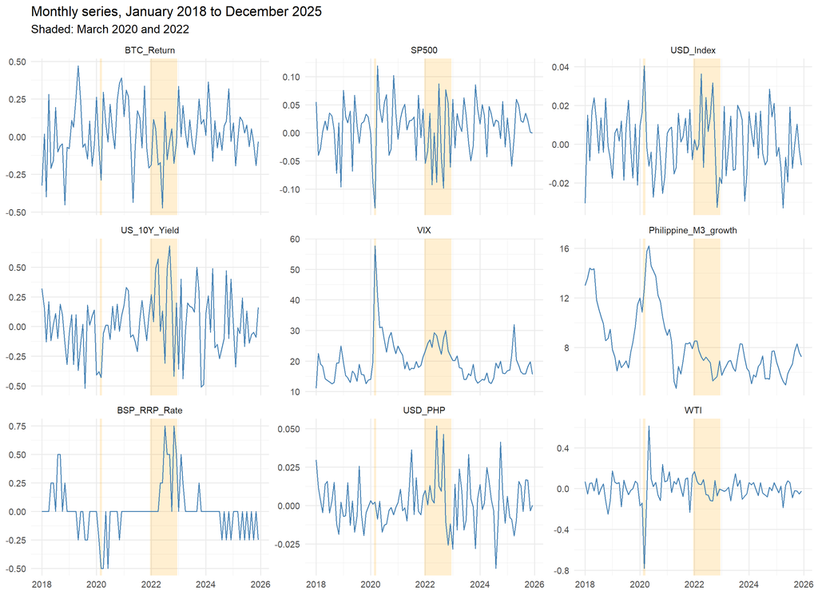

```r
# Shaded episodes (March 2020 and calendar 2022)
episodes <- tibble(label = c("Mar 2020", "2022"),
                   start = ymd(c("2020-02-15", "2021-12-16")),
                   end   = ymd(c("2020-03-16", "2022-12-16")))

to_long(dat) %>%
  ggplot(aes(date, value)) +
  geom_rect(data = episodes, aes(xmin = start, xmax = end, ymin = -Inf, ymax = Inf),
            inherit.aes = FALSE, fill = "orange", alpha = 0.18) +
  geom_line(colour = "steelblue", linewidth = 0.5) +
  facet_wrap(~ variable, ncol = 3, scales = "free_y") +
  labs(title = "Monthly series, January 2018 to December 2025",
       subtitle = "Shaded: March 2020 and 2022", x = NULL, y = NULL)
```

## 4.2 Distributions

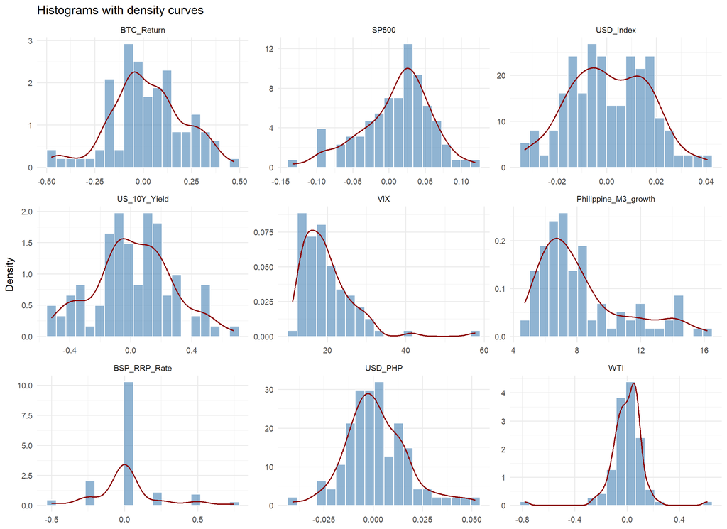

```r
long_all <- to_long(dat)

ggplot(long_all, aes(value)) +
  geom_histogram(aes(y = after_stat(density)), bins = 20,
                 fill = "steelblue", alpha = 0.6, colour = "white") +
  geom_density(colour = "darkred", linewidth = 0.7) +
  facet_wrap(~ variable, ncol = 3, scales = "free") +
  labs(title = "Histograms with density curves", x = NULL, y = "Density")
```

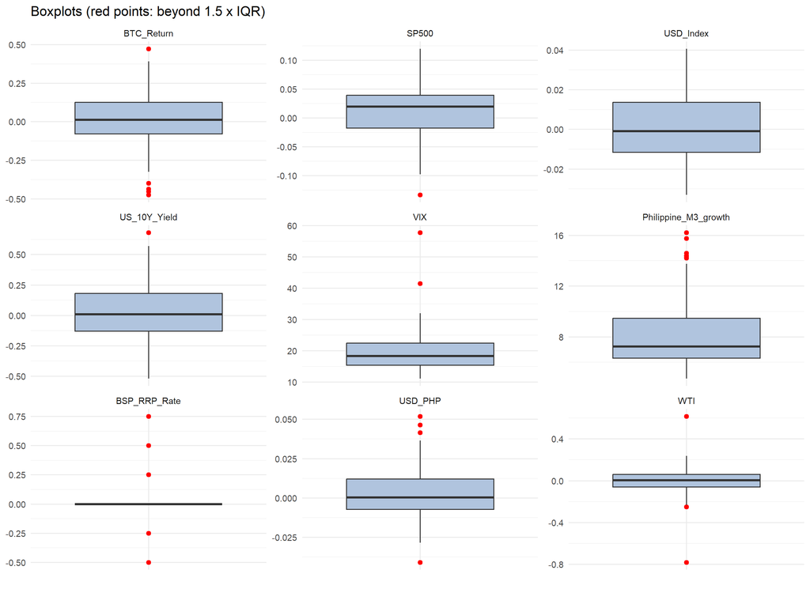

```r
ggplot(long_all, aes(x = "", y = value)) +
  geom_boxplot(fill = "lightsteelblue", outlier.colour = "red", outlier.size = 1.8) +
  facet_wrap(~ variable, ncol = 3, scales = "free_y") +
  labs(title = "Boxplots (red points: beyond 1.5 x IQR)", x = NULL, y = NULL)
```

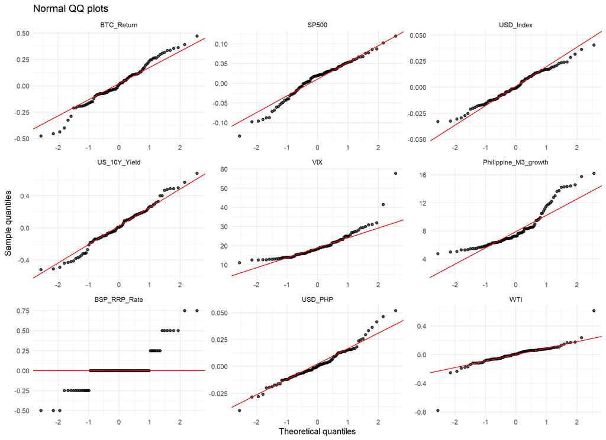

```r
ggplot(long_all, aes(sample = value)) +
  stat_qq(alpha = 0.7) +
  stat_qq_line(colour = "red") +
  facet_wrap(~ variable, ncol = 3, scales = "free") +
  labs(title = "Normal QQ plots", x = "Theoretical quantiles", y = "Sample quantiles")
```

```r
# Supporting evidence only: Jarque-Bera (skewness and kurtosis) and Shapiro-Wilk
norm_tbl <- map_dfr(all_vars, function(v) {
  x  <- dat[[v]]
  jb <- tseries::jarque.bera.test(x)
  sw <- shapiro.test(x)
  tibble(variable = v,
         JB_statistic = unname(jb$statistic), JB_p_value = format.pval(jb$p.value, digits = 3, eps = 1e-4),
         SW_statistic = unname(sw$statistic), SW_p_value = format.pval(sw$p.value, digits = 3, eps = 1e-4))
})
ft(norm_tbl, digits = 4, name = "normality_tests")
```

| variable | JB_statistic | JB_p_value | SW_statistic | SW_p_value |
| --- | --- | --- | --- | --- |
| BTC_Return | 0.3098 | 0.856 | 0.9845 | 0.32 |
| SP500 | 6.0222 | 0.0492 | 0.9694 | 0.0242 |
| USD_Index | 1.0282 | 0.598 | 0.9889 | 0.602 |
| US_10Y_Yield | 0.2045 | 0.903 | 0.9870 | 0.466 |
| VIX | 450.5840 | <1e-04 | 0.8147 | <1e-04 |
| Philippine_M3_growth | 22.6942 | <1e-04 | 0.8678 | <1e-04 |
| BSP_RRP_Rate | 37.7316 | <1e-04 | 0.7618 | <1e-04 |
| USD_PHP | 9.9201 | 0.00701 | 0.9696 | 0.0248 |
| WTI | 788.1791 | <1e-04 | 0.7952 | <1e-04 |

## 4.3 The BSP_RRP_Rate change variable

```r
rrp_dir <- dat %>%
  mutate(direction = case_when(BSP_RRP_Rate > 0 ~ "Hike (positive change)",
                               BSP_RRP_Rate < 0 ~ "Cut (negative change)",
                               TRUE             ~ "No change (zero)"),
         direction = factor(direction, levels = c("Cut (negative change)", "No change (zero)", "Hike (positive change)"))) %>%
  count(direction, .drop = FALSE) %>%
  mutate(share = n / sum(n))
ft(rrp_dir, digits = 3, name = "rrp_direction_counts")
```

| direction | n | share |
| --- | --- | --- |
| Cut (negative change) | 16 | 0.167 |
| No change (zero) | 65 | 0.677 |
| Hike (positive change) | 15 | 0.156 |

```r
rrp_sizes <- dat %>% count(BSP_RRP_Rate) %>% mutate(share = n / sum(n))
ft(rrp_sizes, digits = 3, name = "rrp_size_counts")
```

| BSP_RRP_Rate | n | share |
| --- | --- | --- |
| -0.500 | 3 | 0.031 |
| -0.250 | 13 | 0.135 |
| 0.000 | 65 | 0.677 |
| 0.250 | 7 | 0.073 |
| 0.500 | 6 | 0.062 |
| 0.750 | 2 | 0.021 |

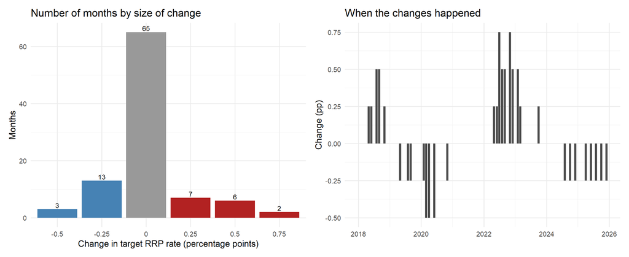

```r
p_sizes <- ggplot(rrp_sizes, aes(factor(BSP_RRP_Rate), n,
                                 fill = case_when(BSP_RRP_Rate > 0 ~ "hike",
                                                  BSP_RRP_Rate < 0 ~ "cut",
                                                  TRUE ~ "none"))) +
  geom_col(show.legend = FALSE) +
  geom_text(aes(label = n), vjust = -0.3, size = 3) +
  scale_fill_manual(values = c(hike = "firebrick", cut = "steelblue", none = "grey60")) +
  labs(title = "Number of months by size of change", x = "Change in target RRP rate (percentage points)", y = "Months")

p_when <- ggplot(dat, aes(date, BSP_RRP_Rate)) +
  geom_col(fill = "grey30", width = 25) +
  labs(title = "When the changes happened", x = NULL, y = "Change (pp)")

p_sizes + p_when
```

```r
# Context: the RRP LEVEL over time (BSP_RRP_Rate.csv runs beyond the sample period)
f_bsp <- find_data("BSP_RRP_Rate.csv")
bsp <- read_csv(f_bsp, show_col_types = FALSE) %>%
  dplyr::select(date, target_rrp = value, overnight_rrp_monthly = on_rrp_overnight_monthly)

cat("BSP file covers", format(min(bsp$date)), "to", format(max(bsp$date)),
    "|", sum(bsp$date > max(dat$date)), "months fall after the BTC sample ends and are not used.\n")
```

```
## BSP file covers 2010-01-01 to 2026-09-01 | 9 months fall after the BTC sample ends and are not used.
```

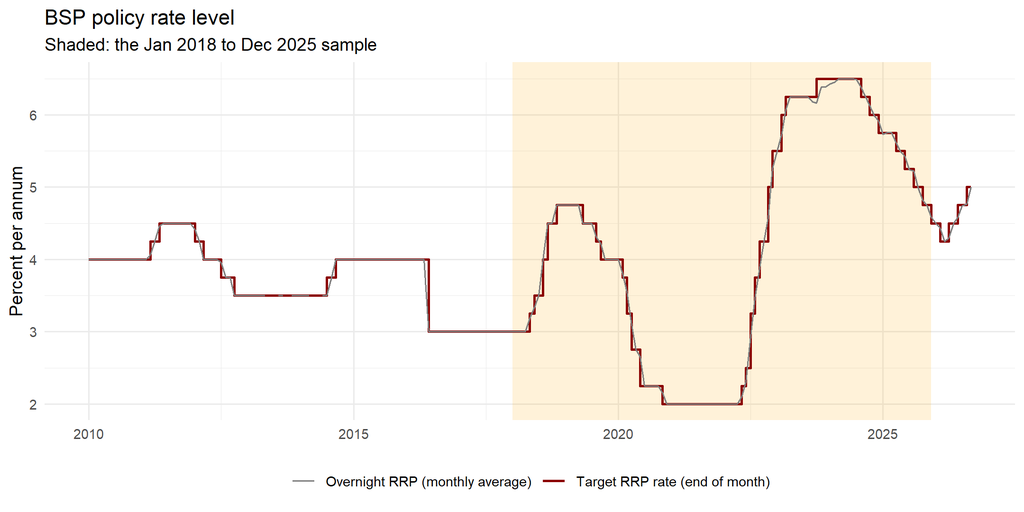

```r
ggplot(bsp, aes(date)) +
  annotate("rect", xmin = min(dat$date), xmax = max(dat$date), ymin = -Inf, ymax = Inf,
           fill = "orange", alpha = 0.15) +
  geom_step(aes(y = target_rrp, colour = "Target RRP rate (end of month)"), linewidth = 0.8) +
  geom_line(aes(y = overnight_rrp_monthly, colour = "Overnight RRP (monthly average)"),
            linewidth = 0.5, na.rm = TRUE) +
  scale_colour_manual(values = c("Target RRP rate (end of month)" = "darkred",
                                 "Overnight RRP (monthly average)" = "grey50")) +
  labs(title = "BSP policy rate level", subtitle = "Shaded: the Jan 2018 to Dec 2025 sample",
       x = NULL, y = "Percent per annum", colour = NULL) +
  theme(legend.position = "bottom")
```

`BSP_RRP_Rate` is a policy rate change, and it is sparse. In 65 of the 96 months (68%) there is no change, and only 31 months have a non-zero change: 13 cuts of 0.25 pp, 3 cuts of 0.50 pp, 7 hikes of 0.25 pp, 6 hikes of 0.50 pp and 2 hikes of 0.75 pp. The changes also arrive in clusters: hikes in 2018, cuts in 2019 and 2020, a tightening cycle from May 2022 to March 2023 (plus one hike in October 2023), and cuts from August 2024 onward.

A histogram of such a variable is one tall spike at zero with a few small bars, so the mean, standard deviation and normality statistics say little (the Jarque-Bera test rejects normality with p below 0.0001). For regression this has three implications. First, the coefficient is identified from only 31 months concentrated in a few episodes that overlap with other major events (COVID-19 in 2020, the 2022 tightening and crypto sell-off), so a policy effect is hard to separate from everything else happening in those months. Second, one slope forces cuts and hikes to have mirror image effects. Third, a one standard deviation move (0.22 pp) is not a move the BSP actually makes, since real moves are zero or multiples of 0.25 pp. The coefficient should be expected to be imprecisely estimated, and separate hike and cut indicators, or the policy rate level, are alternatives worth considering at the modeling stage.

## 4.4 Persistence and volatility clustering

For a series $x_t$ the sample autocorrelation at lag $k$ is

$$\hat{\rho}_k =
\frac{\sum_{t=k+1}^{n}(x_t-\bar{x})(x_{t-k}-\bar{x})}{\sum_{t=1}^{n}(x_t-\bar{x})^2},$$

and the dashed lines in the plots mark the approximate 95% band $\pm 1.96/\sqrt{n}$ under no autocorrelation.

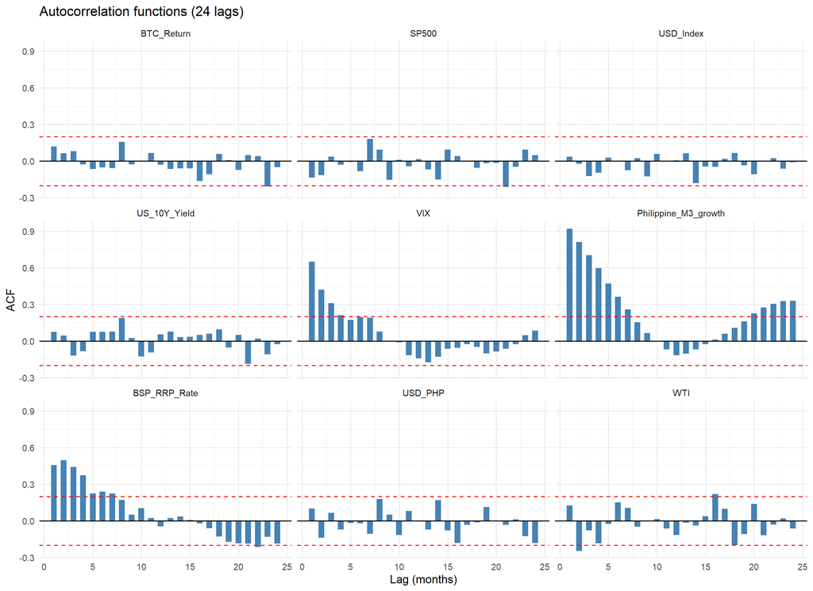

```r
acf_df <- function(x, v, lag.max = 24) {
  a <- acf(x, lag.max = lag.max, plot = FALSE)
  tibble(variable = v,
         lag = as.numeric(a$lag)[-1],
         acf = as.numeric(a$acf)[-1],
         ci  = qnorm(0.975) / sqrt(length(x)))
}

acf_all <- map_dfr(all_vars, ~ acf_df(dat[[.x]], .x)) %>%
  mutate(variable = factor(variable, levels = all_vars))

ggplot(acf_all, aes(lag, acf)) +
  geom_col(fill = "steelblue", width = 0.6) +
  geom_hline(aes(yintercept =  ci), linetype = "dashed", colour = "red") +
  geom_hline(aes(yintercept = -ci), linetype = "dashed", colour = "red") +
  geom_hline(yintercept = 0) +
  facet_wrap(~ variable, ncol = 3) +
  labs(title = "Autocorrelation functions (24 lags)", x = "Lag (months)", y = "ACF")
```

```r
lb_one <- function(x, lag) {
  b <- Box.test(x, lag = lag, type = "Ljung-Box")
  tibble(Q = unname(b$statistic), p_value = b$p.value)
}

# Ljung-Box (lag 12) for every series
lb_all <- map_dfr(all_vars, ~ bind_cols(tibble(series = .x), lb_one(dat[[.x]], 12))) %>%
  mutate(p_value = format.pval(p_value, digits = 3, eps = 1e-4))
ft(lb_all, digits = 3, name = "ljung_box_all_series")
```

| series | Q | p_value |
| --- | --- | --- |
| BTC_Return | 6.892 | 0.865 |
| SP500 | 11.297 | 0.504 |
| USD_Index | 5.502 | 0.939 |
| US_10Y_Yield | 11.636 | 0.475 |
| VIX | 88.993 | <1e-04 |
| Philippine_M3_growth | 284.226 | <1e-04 |
| BSP_RRP_Rate | 100.458 | <1e-04 |
| USD_PHP | 10.966 | 0.532 |
| WTI | 17.521 | 0.131 |

```r
# BTC_Return and its square (squared returns test for volatility clustering)
lb_btc <- expand_grid(series = c("BTC_Return", "BTC_Return squared"), lag = c(6, 12)) %>%
  mutate(res = map2(series, lag, function(s, l) {
    x <- if (s == "BTC_Return") dat$BTC_Return else dat$BTC_Return^2
    lb_one(x, l)
  })) %>%
  unnest(res) %>%
  mutate(p_value = format.pval(p_value, digits = 3, eps = 1e-4))
ft(lb_btc, digits = 3, name = "ljung_box_btc")
```

| series | lag | Q | p_value |
| --- | --- | --- | --- |
| BTC_Return | 6.000 | 3.274 | 0.774 |
| BTC_Return | 12.000 | 6.892 | 0.865 |
| BTC_Return squared | 6.000 | 2.873 | 0.825 |
| BTC_Return squared | 12.000 | 6.810 | 0.870 |

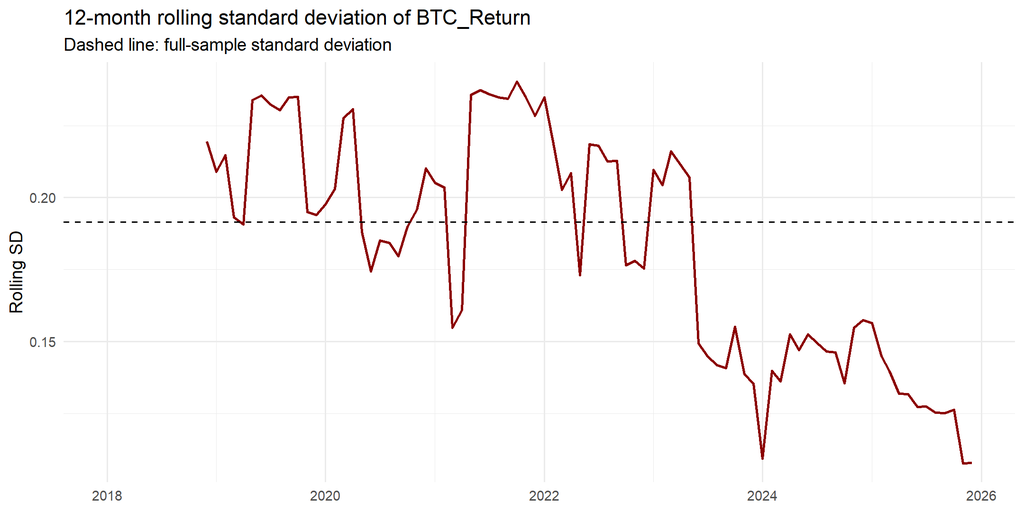

```r
# 12-month rolling standard deviation of BTC_Return
roll_sd <- tibble(date = dat$date,
                  sd_12m = zoo::rollapply(dat$BTC_Return, width = 12, FUN = sd,
                                          align = "right", fill = NA))

ggplot(roll_sd, aes(date, sd_12m)) +
  geom_line(colour = "darkred", linewidth = 0.8, na.rm = TRUE) +
  geom_hline(yintercept = sd(dat$BTC_Return), linetype = "dashed") +
  labs(title = "12-month rolling standard deviation of BTC_Return",
       subtitle = "Dashed line: full-sample standard deviation", x = NULL, y = "Rolling SD")
```

The return type series show little persistence. Their first lag autocorrelations are 0.12 for `BTC_Return`, −0.14 for `SP500`, 0.04 for `USD_Index`, 0.07 for `US_10Y_Yield`, 0.10 for `USD_PHP` and 0.13 for `WTI`, all inside or near the ±0.20 band, and the Ljung-Box test at 12 lags does not reject for any of them (p between 0.13 and 0.94). The slow moving series are the opposite. `Philippine_M3_growth` has a first lag autocorrelation of 0.92 with significant spikes at 12 of 24 lags (not surprising, because a year-on-year rate uses overlapping 12-month windows), `VIX` has 0.65 at lag 1 and 0.42 at lag 2, and `BSP_RRP_Rate` has 0.46 and 0.50 at lags 1 and 2, which reflects policy cycles. The Ljung-Box test rejects no autocorrelation for all three (p below 0.0001).

There is no formal evidence of volatility clustering in Bitcoin: neither `BTC_Return` (Ljung-Box p = 0.77 at 6 lags and 0.86 at 12 lags) nor its square (p = 0.82 and 0.87) is significantly autocorrelated. The rolling standard deviation still drifts, from a peak of 0.24 in October 2021 down to 0.11 in November 2025 (full-sample standard deviation 0.19), so Bitcoin volatility has declined over time.

For the regression residuals, persistent regressors do not by themselves imply autocorrelated errors, and since `BTC_Return` has no serial correlation the residuals may well be close to white noise. The risk is that `Philippine_M3_growth`, `VIX` and `BSP_RRP_Rate` follow slow regimes (such as the 2020 spike) and that the error variance changes over time. Both points should be checked in the residual diagnostics, and heteroskedasticity and autocorrelation consistent (HAC) standard errors are a reasonable safeguard.

# 5 Outliers and extreme months

Each variable is standardized as $z_{t} = \dfrac{x_{t}-\bar{x}}{s}$, and a month is flagged as extreme when $|z_t| > 3$. **No observation is deleted**: the cleaning script keeps legitimate extremes on purpose.

```r
z <- dat %>% mutate(across(all_of(all_vars), ~ as.numeric(scale(.x))))

z_long <- to_long(z) %>% rename(z = value)
raw_long <- to_long(dat)

extreme_long <- z_long %>%
  left_join(raw_long, by = c("date", "variable")) %>%
  filter(abs(z) > 3) %>%
  arrange(date, variable) %>%
  transmute(month = format(date, "%Y-%m"), variable, value, z)
ft(extreme_long, digits = 3, name = "extreme_months")
```

| month | variable | value | z |
| --- | --- | --- | --- |
| 2020-03 | SP500 | -0.134 | -3.008 |
| 2020-03 | VIX | 57.737 | 5.619 |
| 2020-03 | WTI | -0.782 | -5.763 |
| 2020-04 | VIX | 41.454 | 3.212 |
| 2020-05 | WTI | 0.615 | 4.540 |
| 2022-06 | USD_PHP | 0.052 | 3.169 |
| 2022-07 | BSP_RRP_Rate | 0.750 | 3.337 |
| 2022-11 | BSP_RRP_Rate | 0.750 | 3.337 |

```r
# Counts of flagged months per variable under three common rules
out_counts <- z_long %>%
  left_join(raw_long, by = c("date", "variable")) %>%
  group_by(variable) %>%
  summarise(n_abs_z_gt_2 = sum(abs(z) > 2),
            n_abs_z_gt_3 = sum(abs(z) > 3),
            n_boxplot_rule = sum(value < quantile(value, 0.25) - 1.5 * IQR(value) |
                                 value > quantile(value, 0.75) + 1.5 * IQR(value)),
            .groups = "drop")
ft(out_counts, digits = 0, name = "outlier_counts")
```

| variable | n_abs_z_gt_2 | n_abs_z_gt_3 | n_boxplot_rule |
| --- | --- | --- | --- |
| BTC_Return | 5 | 0 | 5 |
| SP500 | 7 | 1 | 1 |
| USD_Index | 4 | 0 | 0 |
| US_10Y_Yield | 4 | 0 | 1 |
| VIX | 2 | 2 | 2 |
| Philippine_M3_growth | 7 | 0 | 7 |
| BSP_RRP_Rate | 11 | 2 | 31 |
| USD_PHP | 5 | 1 | 4 |
| WTI | 2 | 2 | 3 |

```r
# Which variables are extreme together in the same month? (z-scores shown, red cells: |z| > 3)
z_ext <- z %>%
  filter(if_any(all_of(all_vars), ~ abs(.x) > 3)) %>%
  mutate(n_extreme = rowSums(abs(across(all_of(all_vars))) > 3),
         month = format(date, "%Y-%m")) %>%
  dplyr::select(month, n_extreme, all_of(all_vars))

ft(z_ext, digits = 2, name = "extreme_cooccurrence_zscores") %>%
  flextable::bg(j = all_vars, bg = function(x) ifelse(abs(x) > 3, "#f8d7da", "transparent"))
```

| month | n_extreme | BTC_Return | SP500 | USD_Index | US_10Y_Yield | VIX | Philippine_M3_growth | BSP_RRP_Rate | USD_PHP | WTI |
| --- | --- | --- | --- | --- | --- | --- | --- | --- | --- | --- |
| 2020-03 | 3.00 | -1.61 | -3.01 | 2.49 | -1.75 | 5.62 | 1.63 | -2.34 | 0.02 | -5.76 |
| 2020-04 | 1.00 | 1.45 | 2.30 | -0.16 | -0.31 | 3.21 | 2.70 | -2.34 | -0.67 | -0.47 |
| 2020-05 | 1.00 | 0.36 | 0.72 | -0.77 | -0.03 | 1.65 | 2.87 | -0.07 | 0.06 | 4.54 |
| 2022-06 | 1.00 | -2.57 | -2.04 | 1.46 | 0.43 | 1.26 | -0.38 | 1.06 | 3.17 | -0.44 |
| 2022-07 | 1.00 | 0.76 | 1.62 | 0.36 | -1.28 | 0.78 | -0.46 | 3.34 | 0.69 | -0.45 |
| 2022-11 | 1.00 | -1.02 | 0.89 | -2.10 | -1.71 | 0.53 | -0.94 | 3.34 | -1.75 | -0.53 |

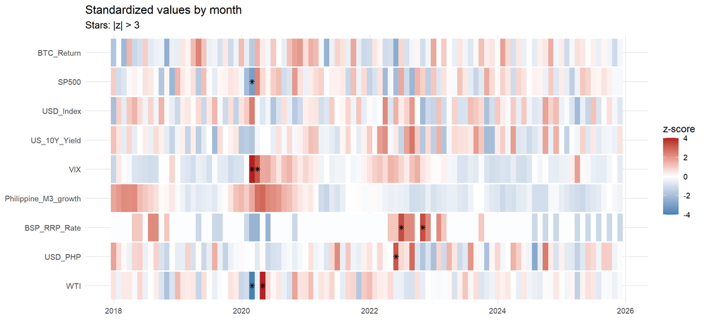

```r
# Heat strip of all z-scores (clipped at +/- 4 for colour); stars mark |z| > 3
z_ext_pts <- z_long %>% filter(abs(z) > 3)

z_long %>%
  mutate(z_clip = pmax(pmin(z, 4), -4)) %>%
  ggplot(aes(date, variable, fill = z_clip)) +
  geom_tile(width = 31, height = 0.95) +
  geom_point(data = z_ext_pts, aes(date, variable), shape = 8, size = 1.6, inherit.aes = FALSE) +
  scale_fill_gradient2(low = "steelblue", mid = "white", high = "firebrick",
                       limits = c(-4, 4), name = "z-score") +
  scale_y_discrete(limits = rev(all_vars)) +
  labs(title = "Standardized values by month", subtitle = "Stars: |z| > 3", x = NULL, y = NULL)
```

Eight variable-month combinations exceed three standard deviations, and they are concentrated in two episodes. In March 2020, during the COVID-19 market crash, three variables are extreme at the same time: `SP500` (−0.134 log, about −12.5%), `VIX` (a monthly average of 57.7, the highest in the sample) and `WTI` (−0.78 log, about −54%, the oil price collapse). `VIX` is still extreme in April 2020 (41.5) and `WTI` rebounds in May 2020 (+0.62). In 2022 the extremes are tied to monetary tightening and market stress: `BSP_RRP_Rate` rose by 0.75 pp in both July and November 2022, and `USD_PHP` jumped by 0.052 log (a peso depreciation of about 5%) in June 2022. June 2022 is also Bitcoin’s worst month, coinciding with stress in crypto markets (the collapse of Terra/Luna and the failure of crypto lenders) while US interest rates were rising, and November 2022 coincides with the collapse of the FTX exchange.

`BTC_Return` itself never exceeds three standard deviations. Its five most extreme months (March 2018, November 2018, May 2019, May 2021 and June 2022) lie between 2.2 and 2.6 standard deviations, and March 2020 (−0.29 log, about −25%) is large but not extreme relative to Bitcoin’s own volatility. March 2020 is the only month in which several variables are extreme together; every other flagged month has a single extreme variable. The boxplot rule flags 31 months for `BSP_RRP_Rate`, but that is an artifact of the zeros collapsing its interquartile range and is not informative.

These months are genuine market events, not data errors, so none was removed. For the modeling stage the following should be considered: heteroskedasticity-robust (for example HC3) or HAC standard errors, dummy variables for March to May 2020 and for 2022, influence diagnostics (leverage, Cook’s distance) for March 2020 and June 2022, and a sensitivity run without these months. Because the `VIX` and `WTI` extremes sit in the same months, their coefficients in particular could be driven by March to May 2020.

# 6 Bivariate analysis

## 6.1 Each regressor against BTC_Return

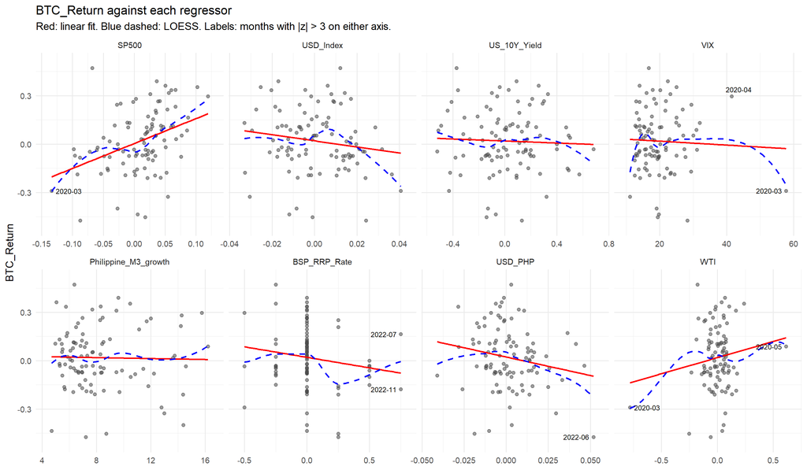

```r
biv <- dat %>%
  mutate(zy = as.numeric(scale(BTC_Return))) %>%
  pivot_longer(all_of(x_vars), names_to = "regressor", values_to = "x") %>%
  mutate(regressor = factor(regressor, levels = x_vars)) %>%
  group_by(regressor) %>%
  mutate(zx = as.numeric(scale(x))) %>%
  ungroup() %>%
  mutate(lab = if_else(abs(zx) > 3 | abs(zy) > 3, format(date, "%Y-%m"), NA_character_))

ggplot(biv, aes(x, BTC_Return)) +
  geom_point(alpha = 0.55, colour = "grey30") +
  geom_smooth(method = "lm", formula = y ~ x, se = FALSE, colour = "red", linewidth = 0.8) +
  geom_smooth(method = "loess", formula = y ~ x, se = FALSE, colour = "blue",
              linetype = "dashed", linewidth = 0.8) +
  geom_text_repel(aes(label = lab), size = 2.6, na.rm = TRUE, max.overlaps = Inf) +
  scale_y_continuous(expand = expansion(mult = 0.1)) +
  scale_x_continuous(expand = expansion(mult = 0.1)) +
  facet_wrap(~ regressor, ncol = 4, scales = "free_x") +
  labs(title = "BTC_Return against each regressor",
       subtitle = "Red: linear fit. Blue dashed: LOESS. Labels: months with |z| > 3 on either axis.",
       x = NULL, y = "BTC_Return")
```

```r
cor_raw <- map_dfr(x_vars, function(v) {
  p <- cor.test(dat[[v]], dat$BTC_Return, method = "pearson")
  s <- suppressWarnings(cor.test(dat[[v]], dat$BTC_Return, method = "spearman", exact = FALSE))
  tibble(regressor = v,
         pearson_r = unname(p$estimate), pearson_p = p$p.value,
         spearman_rho = unname(s$estimate), spearman_p = s$p.value,
         gap = pearson_r - spearman_rho)
}) %>%
  arrange(desc(abs(pearson_r)))

# A large gap between Pearson and Spearman can mean a few outliers drive the linear relationship
cor_tbl <- cor_raw %>%
  mutate(large_gap = abs(gap) > 0.10,
         across(c(pearson_p, spearman_p), ~ format.pval(.x, digits = 3, eps = 1e-4)))
ft(cor_tbl, digits = 3, name = "correlations_with_btc")
```

| regressor | pearson_r | pearson_p | spearman_rho | spearman_p | gap | large_gap |
| --- | --- | --- | --- | --- | --- | --- |
| SP500 | 0.385 | 0.000109 | 0.408 | <1e-04 | -0.023 | false |
| USD_PHP | -0.189 | 0.064685 | -0.178 | 0.0822 | -0.011 | false |
| USD_Index | -0.158 | 0.123897 | -0.191 | 0.0621 | 0.033 | false |
| BSP_RRP_Rate | -0.150 | 0.144832 | -0.139 | 0.1761 | -0.011 | false |
| WTI | 0.142 | 0.168753 | 0.040 | 0.6968 | 0.101 | true |
| VIX | -0.043 | 0.676037 | 0.020 | 0.8475 | -0.063 | false |
| US_10Y_Yield | -0.042 | 0.684650 | 0.005 | 0.9603 | -0.047 | false |
| Philippine_M3_growth | -0.021 | 0.836676 | -0.066 | 0.5208 | 0.045 | false |

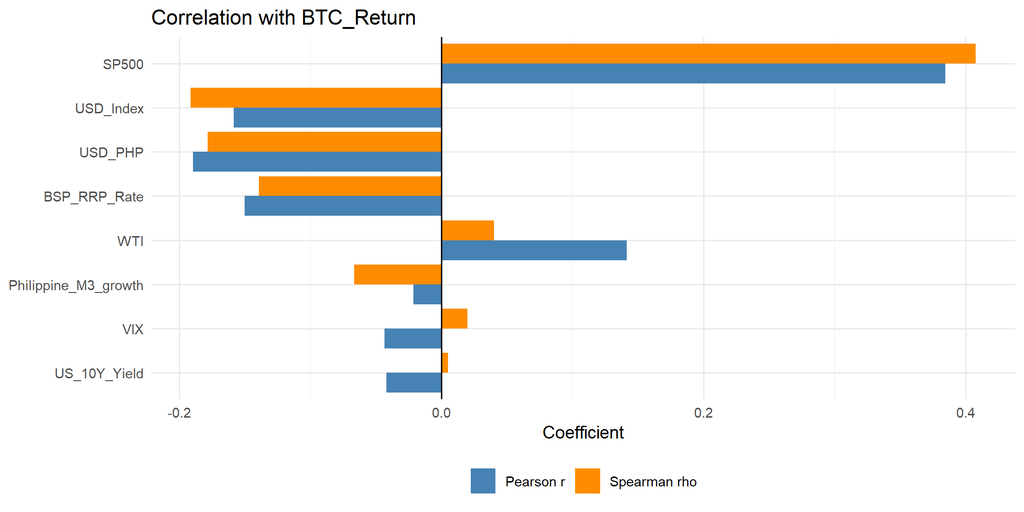

```r
cor_raw %>%
  pivot_longer(c(pearson_r, spearman_rho), names_to = "type", values_to = "coef") %>%
  mutate(regressor = fct_reorder(regressor, abs(coef), .fun = max)) %>%
  ggplot(aes(regressor, coef, fill = type)) +
  geom_col(position = "dodge") +
  geom_hline(yintercept = 0) +
  coord_flip() +
  scale_fill_manual(values = c(pearson_r = "steelblue", spearman_rho = "darkorange"),
                    labels = c("Pearson r", "Spearman rho"), name = NULL) +
  labs(title = "Correlation with BTC_Return", x = NULL, y = "Coefficient") +
  theme(legend.position = "bottom")
```

Only `SP500` has a clear relationship with `BTC_Return`. The correlation is positive, 0.39 (Pearson, p = 0.0001) and 0.41 (Spearman), so Bitcoin tends to rise in months when US equities rise, consistent with Bitcoin trading as a risk asset over this period. It is the only result that survives a correction for testing eight regressors (Bonferroni threshold 0.05/8 = 0.006), and the near-identical Pearson and Spearman values show it is not driven by a few outliers.

The other relationships are weak. `USD_PHP` (−0.19, p = 0.065), `USD_Index` (−0.16, p = 0.12) and `BSP_RRP_Rate` (−0.15, p = 0.15) have negative signs, in line with the idea that a stronger dollar, a weaker peso and tighter local monetary policy go with weaker Bitcoin returns, but none is significant at the 5% level. `USD_PHP` and `USD_Index` are correlated with each other (0.51), so they probably carry overlapping information. `WTI` has a Pearson correlation of 0.14 (p = 0.17) but a Spearman correlation of only 0.04, the largest gap (0.10) of all regressors, which suggests that a few extreme months, mainly March to May 2020, drive its linear relationship. `US_10Y_Yield` (−0.04), `VIX` (−0.04) and `Philippine_M3_growth` (−0.02) show essentially no linear association with `BTC_Return`. The LOESS curves mostly follow the straight lines except at the sparse ends of the x ranges, where they rest on a handful of points, so there is no strong evidence of nonlinearity. All of this describes co-movement in this sample; it is not evidence that any regressor causes Bitcoin returns to move.

## 6.2 Stability over time

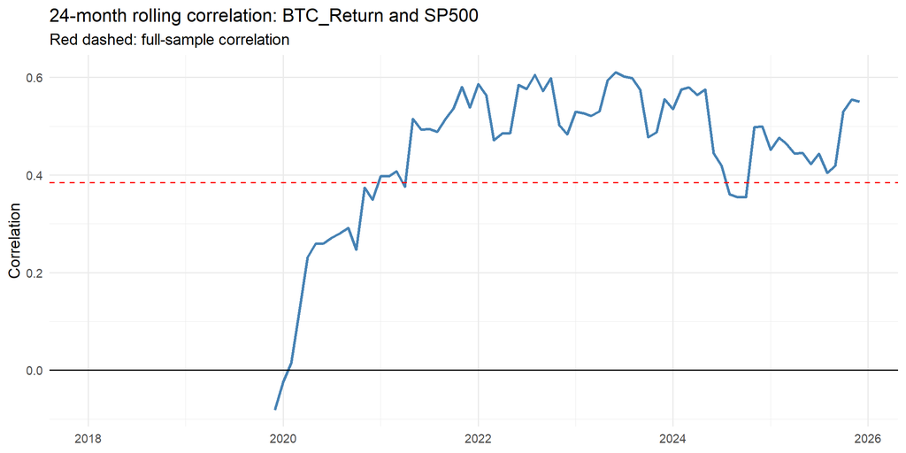

```r
# 24-month rolling correlation
roll_cor <- function(x, y, w = 24) {
  suppressWarnings(
    zoo::rollapply(cbind(x, y), width = w, FUN = function(m) cor(m[, 1], m[, 2]),
                   by.column = FALSE, align = "right", fill = NA)
  )
}

rc_sp <- tibble(date = dat$date, rho = roll_cor(dat$BTC_Return, dat$SP500))

ggplot(rc_sp, aes(date, rho)) +
  geom_line(colour = "steelblue", linewidth = 0.9, na.rm = TRUE) +
  geom_hline(yintercept = 0) +
  geom_hline(yintercept = cor(dat$BTC_Return, dat$SP500), linetype = "dashed", colour = "red") +
  labs(title = "24-month rolling correlation: BTC_Return and SP500",
       subtitle = "Red dashed: full-sample correlation", x = NULL, y = "Correlation")
```

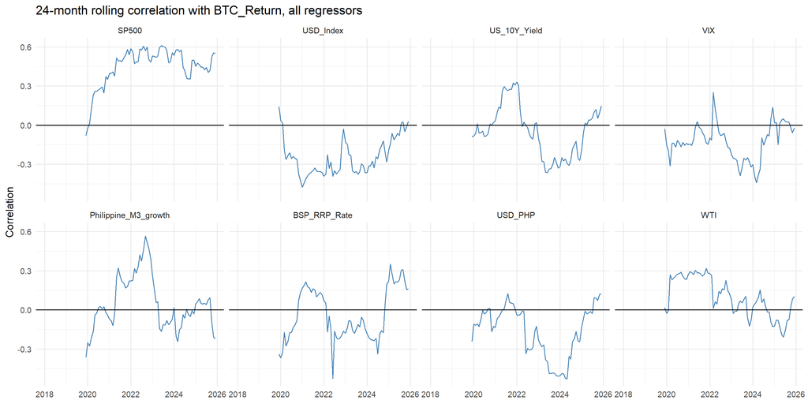

```r
rc_all <- map_dfr(x_vars, ~ tibble(date = dat$date, regressor = .x,
                                   rho = roll_cor(dat$BTC_Return, dat[[.x]]))) %>%
  mutate(regressor = factor(regressor, levels = x_vars))

ggplot(rc_all, aes(date, rho)) +
  geom_line(colour = "steelblue", na.rm = TRUE) +
  geom_hline(yintercept = 0) +
  facet_wrap(~ regressor, ncol = 4) +
  labs(title = "24-month rolling correlation with BTC_Return, all regressors", x = NULL, y = "Correlation")
```

```r
dat_p <- dat %>%
  mutate(period = factor(if_else(date < ymd("2022-01-01"), "2018-2021", "2022-2025")))

sub_cor <- dat_p %>%
  pivot_longer(all_of(x_vars), names_to = "regressor", values_to = "x") %>%
  mutate(regressor = factor(regressor, levels = x_vars)) %>%
  group_by(period, regressor) %>%
  summarise(n = n(),
            r = cor(x, BTC_Return),
            ci_low  = cor.test(x, BTC_Return)$conf.int[1],
            ci_high = cor.test(x, BTC_Return)$conf.int[2],
            .groups = "drop")

# Side-by-side table with the change between periods
sub_wide <- sub_cor %>%
  dplyr::select(period, regressor, r) %>%
  pivot_wider(names_from = period, values_from = r, names_prefix = "r_") %>%
  mutate(change = `r_2022-2025` - `r_2018-2021`)
ft(sub_wide, digits = 3, name = "subperiod_correlations")
```

| regressor | r_2018-2021 | r_2022-2025 | change |
| --- | --- | --- | --- |
| SP500 | 0.280 | 0.553 | 0.273 |
| USD_Index | -0.121 | -0.215 | -0.094 |
| US_10Y_Yield | 0.106 | -0.184 | -0.289 |
| VIX | 0.037 | -0.236 | -0.273 |
| Philippine_M3_growth | -0.026 | -0.159 | -0.133 |
| BSP_RRP_Rate | -0.191 | -0.111 | 0.079 |
| USD_PHP | -0.129 | -0.270 | -0.142 |
| WTI | 0.190 | -0.015 | -0.205 |

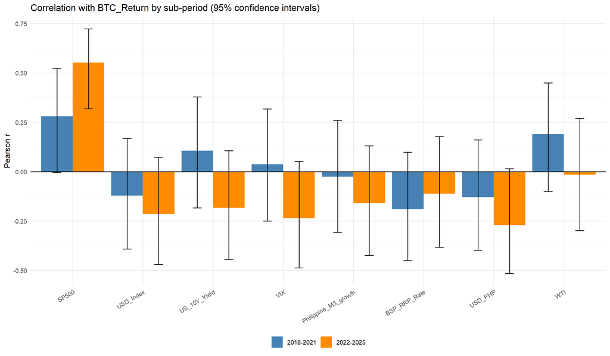

```r
ggplot(sub_cor, aes(regressor, r, fill = period)) +
  geom_col(position = position_dodge(0.9)) +
  geom_errorbar(aes(ymin = ci_low, ymax = ci_high), position = position_dodge(0.9), width = 0.25) +
  geom_hline(yintercept = 0) +
  scale_fill_manual(values = c("2018-2021" = "steelblue", "2022-2025" = "darkorange")) +
  labs(title = "Correlation with BTC_Return by sub-period (95% confidence intervals)",
       x = NULL, y = "Pearson r", fill = NULL) +
  theme(axis.text.x = element_text(angle = 30, hjust = 1), legend.position = "bottom")
```

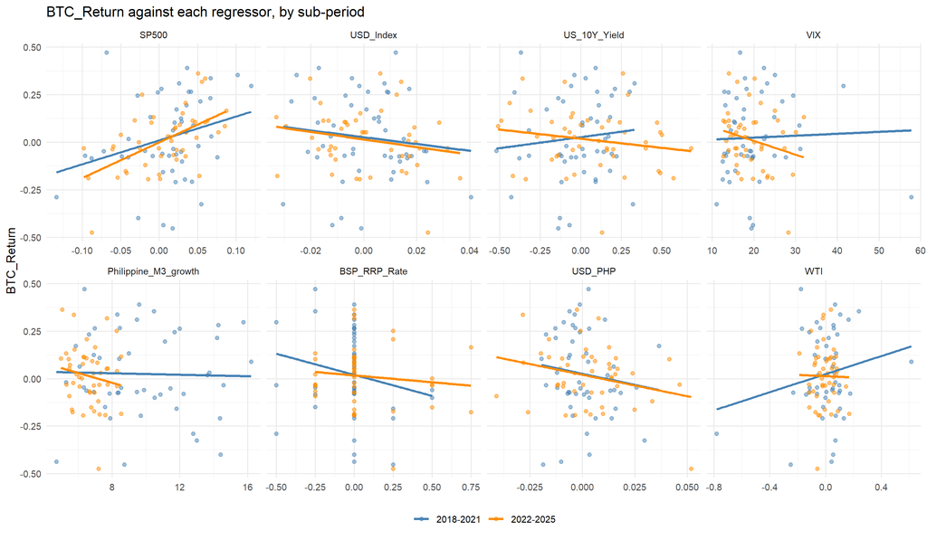

```r
# Scatter plots by sub-period
dat_p %>%
  pivot_longer(all_of(x_vars), names_to = "regressor", values_to = "x") %>%
  mutate(regressor = factor(regressor, levels = x_vars)) %>%
  ggplot(aes(x, BTC_Return, colour = period)) +
  geom_point(alpha = 0.5) +
  geom_smooth(method = "lm", formula = y ~ x, se = FALSE) +
  scale_colour_manual(values = c("2018-2021" = "steelblue", "2022-2025" = "darkorange")) +
  facet_wrap(~ regressor, ncol = 4, scales = "free_x") +
  labs(title = "BTC_Return against each regressor, by sub-period", x = NULL, colour = NULL) +
  theme(legend.position = "bottom")
```

The other regressors show sign changes between the sub-periods (`US_10Y_Yield` from 0.11 to −0.18, `VIX` from 0.04 to −0.24, `WTI` from 0.19 to −0.02), but with only 48 months in each sub-period the 95% intervals are wide (about ±0.28) and nearly all include zero, so these shifts cannot be separated from sampling noise. Bitcoin’s own volatility also fell between the periods (standard deviation 0.22 versus 0.16), which points to robust standard errors.

The evidence supports allowing for regime dependence in the `SP500` relationship, for example an interaction between `SP500` and a post-2020 (or 2022 onward) indicator. For the other regressors there is not enough evidence to justify extra terms. Whether the interaction is needed should be tested formally in the modeling stage (for example with a significance test of the interaction or a Chow type test) rather than judged from this exploratory analysis.

# 7 Multivariate analysis

## 7.1 Correlations among the regressors

```r
cor_mat <- cor(dat[x_vars])

cor_mat %>% round(2) %>% as.data.frame() %>% rownames_to_column("variable") %>% ft(digits = 2, name = "correlation_matrix_regressors")
```

| variable | SP500 | USD_Index | US_10Y_Yield | VIX | Philippine_M3_growth | BSP_RRP_Rate | USD_PHP | WTI |
| --- | --- | --- | --- | --- | --- | --- | --- | --- |
| SP500 | 1.00 | -0.55 | -0.19 | -0.25 | -0.00 | -0.02 | -0.31 | 0.41 |
| USD_Index | -0.55 | 1.00 | 0.30 | 0.08 | 0.02 | 0.01 | 0.51 | -0.28 |
| US_10Y_Yield | -0.19 | 0.30 | 1.00 | -0.00 | -0.01 | 0.13 | 0.28 | 0.28 |
| VIX | -0.25 | 0.08 | -0.00 | 1.00 | 0.31 | -0.19 | -0.05 | -0.30 |
| Philippine_M3_growth | -0.00 | 0.02 | -0.01 | 0.31 | 1.00 | -0.16 | -0.04 | 0.07 |
| BSP_RRP_Rate | -0.02 | 0.01 | 0.13 | -0.19 | -0.16 | 1.00 | 0.14 | 0.07 |
| USD_PHP | -0.31 | 0.51 | 0.28 | -0.05 | -0.04 | 0.14 | 1.00 | 0.04 |
| WTI | 0.41 | -0.28 | 0.28 | -0.30 | 0.07 | 0.07 | 0.04 | 1.00 |

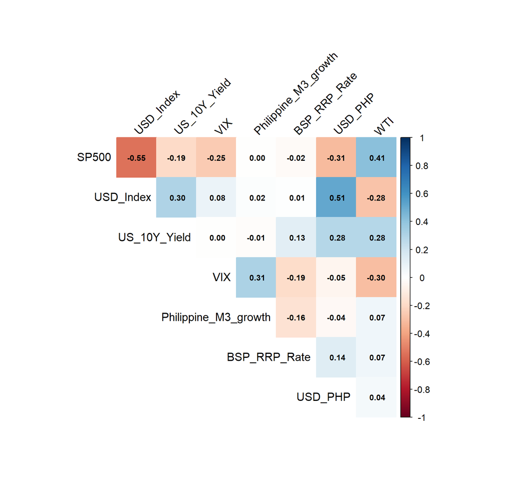

```r
corrplot(cor_mat, method = "color", type = "upper", diag = FALSE,
         addCoef.col = "black", number.cex = 0.7,
         tl.col = "black", tl.srt = 45, col = COL2("RdBu", 200))
```

```r
# Ten most correlated pairs of regressors
pairs_tbl <- as.data.frame(as.table(cor_mat)) %>%
  rename(var1 = Var1, var2 = Var2, r = Freq) %>%
  filter(as.integer(var1) < as.integer(var2)) %>%
  arrange(desc(abs(r))) %>%
  slice_head(n = 10)
ft(pairs_tbl, digits = 3, name = "top_correlated_pairs")
```

| var1 | var2 | r |
| --- | --- | --- |
| SP500 | USD_Index | -0.549 |
| USD_Index | USD_PHP | 0.513 |
| SP500 | WTI | 0.413 |
| SP500 | USD_PHP | -0.313 |
| VIX | Philippine_M3_growth | 0.312 |
| VIX | WTI | -0.303 |
| USD_Index | US_10Y_Yield | 0.300 |
| US_10Y_Yield | USD_PHP | 0.285 |
| USD_Index | WTI | -0.282 |
| US_10Y_Yield | WTI | 0.282 |

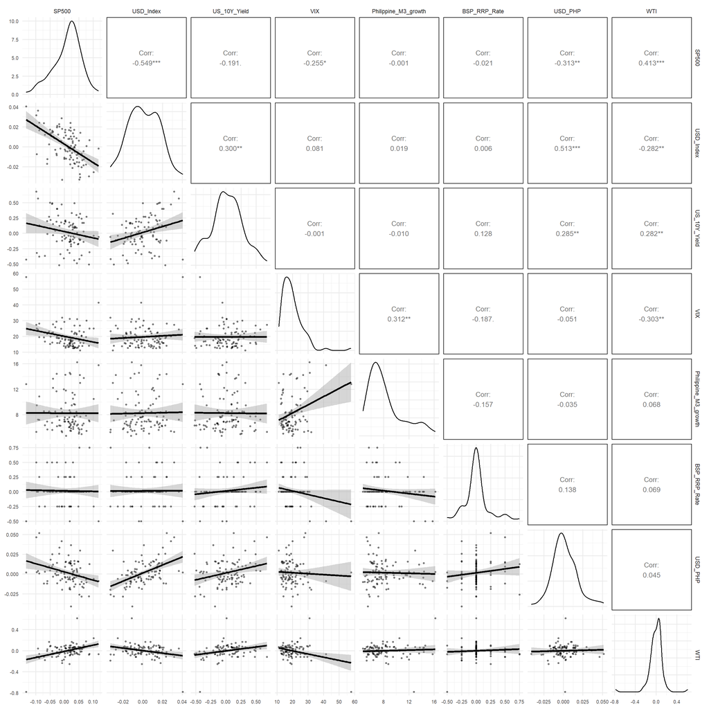

```r
ggpairs(dat[x_vars],
        lower = list(continuous = wrap("smooth", alpha = 0.4, size = 0.6)),
        upper = list(continuous = wrap("cor", size = 3)),
        diag  = list(continuous = wrap("densityDiag"))) +
  theme(axis.text = element_text(size = 6), strip.text = element_text(size = 7))
```

```r
# Optional supporting view: principal components of the standardized regressors
pca <- prcomp(dat[x_vars], scale. = TRUE)
pve <- tibble(PC = factor(paste0("PC", seq_along(pca$sdev)), levels = paste0("PC", seq_along(pca$sdev))),
              eigenvalue = pca$sdev^2) %>%
  mutate(prop = eigenvalue / sum(eigenvalue), cumulative = cumsum(prop))
ft(pve, digits = 3, name = "pca_variance")
```

| PC | eigenvalue | prop | cumulative |
| --- | --- | --- | --- |
| PC1 | 2.220 | 0.278 | 0.278 |
| PC2 | 1.687 | 0.211 | 0.488 |
| PC3 | 1.236 | 0.154 | 0.643 |
| PC4 | 0.856 | 0.107 | 0.750 |
| PC5 | 0.738 | 0.092 | 0.842 |
| PC6 | 0.545 | 0.068 | 0.910 |
| PC7 | 0.408 | 0.051 | 0.961 |
| PC8 | 0.309 | 0.039 | 1.000 |

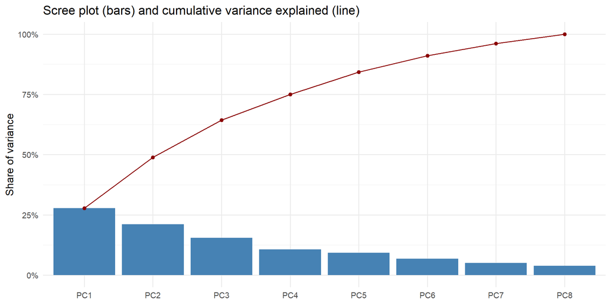

```r
ggplot(pve, aes(PC, prop)) +
  geom_col(fill = "steelblue") +
  geom_line(aes(y = cumulative, group = 1), colour = "darkred") +
  geom_point(aes(y = cumulative), colour = "darkred") +
  scale_y_continuous(labels = scales::percent) +
  labs(title = "Scree plot (bars) and cumulative variance explained (line)", x = NULL, y = "Share of variance")
```

```r
pca$rotation[, 1:3] %>% as.data.frame() %>% rownames_to_column("variable") %>% ft(digits = 3, name = "pca_loadings")
```

| variable | PC1 | PC2 | PC3 |
| --- | --- | --- | --- |
| SP500 | -0.547 | 0.119 | 0.126 |
| USD_Index | 0.570 | 0.081 | -0.008 |
| US_10Y_Yield | 0.261 | 0.408 | 0.409 |
| VIX | 0.207 | -0.501 | 0.285 |
| Philippine_M3_growth | 0.027 | -0.293 | 0.654 |
| BSP_RRP_Rate | 0.036 | 0.391 | -0.256 |
| USD_PHP | 0.424 | 0.336 | 0.091 |
| WTI | -0.288 | 0.459 | 0.484 |

## 7.2 Preliminary check for multicollinearity

For regressor $j$, the variance inflation factor is

$$\text{VIF}_j = \frac{1}{1-R_j^2},$$

where $R_j^2$ comes from regressing $x_j$ on the other regressors. The regression below is fitted **only** to obtain VIFs, not to choose a model.

```r
vif_fit <- lm(reformulate(x_vars, response = y_var), data = dat)
vif_vals <- car::vif(vif_fit)

vif_tbl <- tibble(regressor = names(vif_vals), VIF = as.numeric(vif_vals)) %>%
  mutate(tolerance = 1 / VIF) %>%
  arrange(desc(VIF))
ft(vif_tbl, digits = 3, name = "vif")
```

| regressor | VIF | tolerance |
| --- | --- | --- |
| USD_Index | 1.973 | 0.507 |
| SP500 | 1.727 | 0.579 |
| WTI | 1.708 | 0.586 |
| USD_PHP | 1.494 | 0.669 |
| US_10Y_Yield | 1.394 | 0.717 |
| VIX | 1.341 | 0.746 |
| Philippine_M3_growth | 1.171 | 0.854 |
| BSP_RRP_Rate | 1.086 | 0.921 |

```r
# Condition number of the correlation matrix of the regressors
ev <- eigen(cor_mat)$values
cat("Condition number (sqrt of largest / smallest eigenvalue):", round(sqrt(max(ev) / min(ev)), 2), "\n")
```

```
## Condition number (sqrt of largest / smallest eigenvalue): 2.68
```

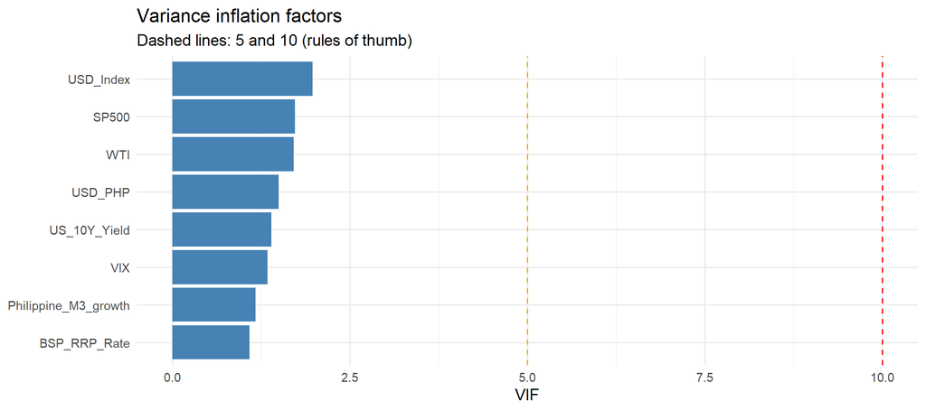

```r
ggplot(vif_tbl, aes(fct_reorder(regressor, VIF), VIF)) +
  geom_col(fill = "steelblue") +
  geom_hline(yintercept = c(5, 10), linetype = "dashed", colour = c("orange", "red")) +
  coord_flip() +
  labs(title = "Variance inflation factors", subtitle = "Dashed lines: 5 and 10 (rules of thumb)",
       x = NULL, y = "VIF")
```

The regressors are only moderately correlated. The strongest pairs are `SP500` and `USD_Index` (−0.55: equities tend to fall when the dollar strengthens) and `USD_Index` and `USD_PHP` (0.51: a stronger dollar goes with a weaker peso), followed by `SP500` and `WTI` (0.41), `SP500` and `USD_PHP` (−0.31), `VIX` and `Philippine_M3_growth` (0.31) and `VIX` and `WTI` (−0.30). Only two pairs exceed 0.5 in absolute value and none exceeds 0.7.

The variance inflation factors are all below 2: the highest is `USD_Index` (1.97), followed by `SP500` (1.73) and `WTI` (1.71), and the lowest is `BSP_RRP_Rate` (1.09). The condition number of the correlation matrix is 2.7, far from the usual warning levels (VIF above 5 or 10, condition number above about 30). The principal components agree: the first explains only 28% of the variance (an axis contrasting dollar strength with equities and oil) and five components are needed to reach 84%, so the regressors carry largely distinct information.

Multicollinearity is therefore not a concern for the planned model. A large VIF would be a warning and not an automatic reason to drop a variable, and no value here calls for that. The dollar block (`USD_Index`, `USD_PHP` and `SP500`) is the one to watch if coefficient signs look unstable.

# 8 Summary of findings and handoff notes

**Data quality and units.** The cleaned file has 96 complete monthly observations from January 2018 to December 2025 with regular one-month spacing, and every variable reconciles with the levels file. The variables are in mixed units (decimal log returns, percentage point changes, an index level and a percent growth rate), so coefficients will not be directly comparable and economic significance should be judged with one standard deviation moves.

**Dependent variable.** `BTC_Return` is highly volatile (about 66% annualized, four times the S&P 500) but statistically well behaved: it is nearly symmetric with kurtosis of 3.05, passes the normality tests, and shows no autocorrelation and no sign of volatility clustering. Its volatility has declined over time (monthly standard deviation 0.22 in 2018 to 2021 versus 0.16 in 2022 to 2025).

**Regressors.** `VIX`, `WTI`, `Philippine_M3_growth` and `BSP_RRP_Rate` are clearly non-normal. `Philippine_M3_growth`, `VIX` and `BSP_RRP_Rate` are persistent, and `BSP_RRP_Rate` is also sparse (68% zeros, 31 non-zero months in a few clusters). Extreme months are few (eight variable-months beyond three standard deviations) and concentrated in March 2020 and 2022; they were kept as genuine market events.

**Relationships.** `SP500` is the only regressor with a clear positive association with `BTC_Return` (r = 0.39), and it strengthened after 2020 (rolling correlation of about 0.5 since 2021). The other regressors have weak associations (absolute correlation of at most 0.19, none significant at 5%), with intuitive signs for `USD_Index`, `USD_PHP` and `BSP_RRP_Rate` and a `WTI` relationship that depends on a few months. The regressors are not collinear: the largest VIF is 1.97 and only two pairs have an absolute correlation above 0.5.

**Handoff note for the modeling team.**

- A baseline OLS of `BTC_Return` on the eight regressors is a sensible start; multicollinearity is not a constraint.
- Use HC (for example HC3) or HAC standard errors and test the residuals for heteroskedasticity and serial correlation, because volatility changed across periods and `VIX`, `Philippine_M3_growth` and `BSP_RRP_Rate` are persistent.
- Consider dummies for March to May 2020 and for 2022, run influence diagnostics for March 2020 and June 2022, and compare results without these months. Do not delete them by default.
- Consider and test an interaction between `SP500` and a post-2020 (or 2022 onward) indicator.
- Expect a weakly identified coefficient for `BSP_RRP_Rate`; hike and cut indicators or the policy rate level are alternatives.
- Standardize the regressors when comparing effect sizes. `VIX` and `Philippine_M3_growth` are levels while the others are changes or returns, so check their stationarity (for example with an ADF test) and consider changes if needed.
- `Philippine_M3_growth` is year-on-year growth as built in the cleaning script, and that definition was not checked against the master metadata dictionary. If the dictionary specifies a different definition, rerun the cleaning script with another `M3_MODE` and repeat the M3 plots and correlations.

# 9 Reproducibility

```r
# Figures (PNG) and tables (CSV) saved by this run. The knitted HTML report itself is
# written to the same folder when knitting finishes.
cat("Output folder:", OUT_DIR, "\n")
```

```
## Output folder: C:/Users/mchin/OneDrive/Desktop/College/7 (1st Term)/FINARTS/R Project/CASE 1 - Bitcoin (BTC) - EDA/02 - Outputs
```

```r
list.files(OUT_DIR, recursive = TRUE)
```

```
##  [1] "BTC_EDA.html"
##  [2] "figures/autocorrelation_plots-1.png"
##  [3] "figures/bsp_context-1.png"
##  [4] "figures/correlation_matrix-1.png"
##  [5] "figures/correlations_with_btc-1.png"
##  [6] "figures/distribution_plots_box-1.png"
##  [7] "figures/distribution_plots_hist-1.png"
##  [8] "figures/distribution_plots_qq-1.png"
##  [9] "figures/ljung_box_and_rolling_sd-1.png"
## [10] "figures/outlier_cooccurrence-1.png"
## [11] "figures/pairs_plot-1.png"
## [12] "figures/pca_optional-1.png"
## [13] "figures/preliminary_vif-1.png"
## [14] "figures/rolling_correlation-1.png"
## [15] "figures/rolling_correlation_all-1.png"
```

[output cut: 27 more lines]